# Analysis - Daims Nitrospira 9 GWW assembly

Mads Albertsen

November 24, 2015

## Introduction

This report documents the binning of a Nitrospira genome from the GWW sample. See [Daims et al., 2015: Complete Nitrification by Nitrospira Bacteria](https://doi.org/10.1038/nature16461) for further details.

## Load the mmgenome package

The metagenome data is analysed using the [mmgenome package](http://madsalbertsen.github.io/mmgenome/).

```r
library("mmgenome")
```

## Import data

The Rmarkdown file [Load_data.Rmd](http://madsalbertsen.github.io/mmgenome/Daims_GWW_Load_data.html) describes the loading of the data and can be imported using the `mmimport` function. However, the preprocessed data can also be downloaded directly from figshare: [Daims_GWW](http://dx.doi.org/10.6084/m9.figshare.1613284). Hence, here we import the prepocessed data from figshare instead.

```r
load("Daims_GWW.RData")
```

## Extract Nitrospira 9

As seen from the overview plots, there are numerous Nitrospira species. This one is located between multiple other species.

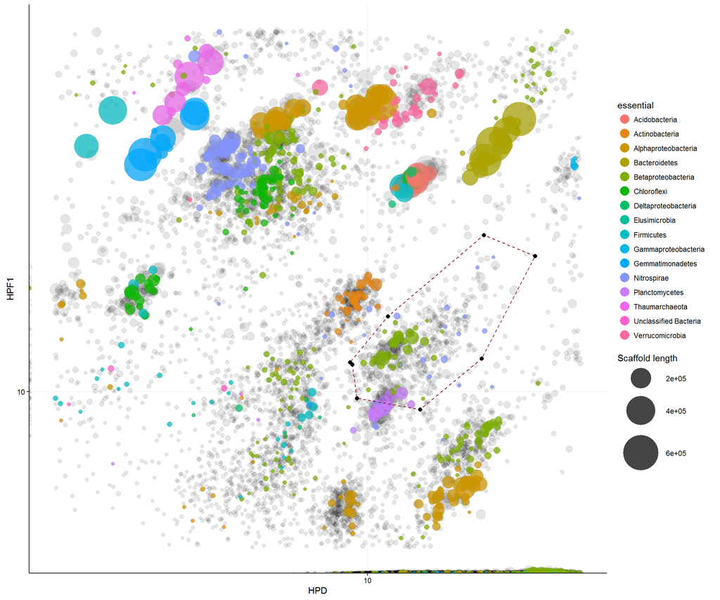

```r
p <- mmplot(data = d,
            x = "HPD",
            y = "HPF1",
            log.x = T,
            log.y = T,
            color = "essential",
            minlength = 5000,
            factor.shape = "solid") +
  scale_x_log10(limits=c(2, 30)) +
  scale_y_log10(limits=c(5, 50))

#p
#sel <- mmplot_locator(p)

sel <- data.frame(HPD  =  c(9.24, 9.46, 13.1, 18, 23.7, 18.2, 11.1, 9.14),
                  HPF1  =  c(11.3, 9.72, 9.24, 11.6, 18.3, 20.1, 14, 11.4))

mmplot_selection(p, sel)
```

The scaffolds included in the defined subspace are extracted using the `mmextract` function.

```r
dA <- mmextract(d, sel)
```

The `mmstats` function applies to any extracted object. Hence, it can be used directly on the subset.

```r
mmstats(dA, ncov = 2)
```

```
##               General Stats
## n.scaffolds         1897.00
## GC.mean               60.20
## N50                11573.00
## Length.total    11385458.00
## Length.max        137749.00
## Length.mean         6001.80
## Coverage.HPD          12.96
## Coverage.HPF1         12.06
## Ess.total            205.00
## Ess.unique           105.00
```

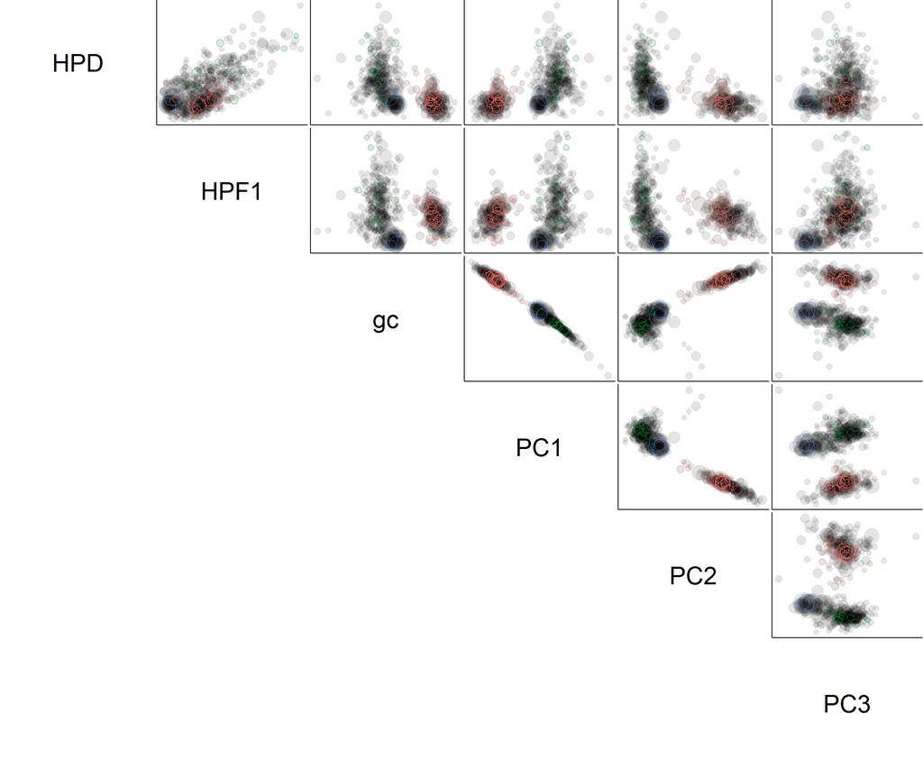

```r
mmplot_pairs(data = dA,
             variables = c("HPD", "HPF1","gc", "PC1", "PC2", "PC3"),
             minlength = 5000,
             color = "essential")
```

## Clean-up other species (Subset B)

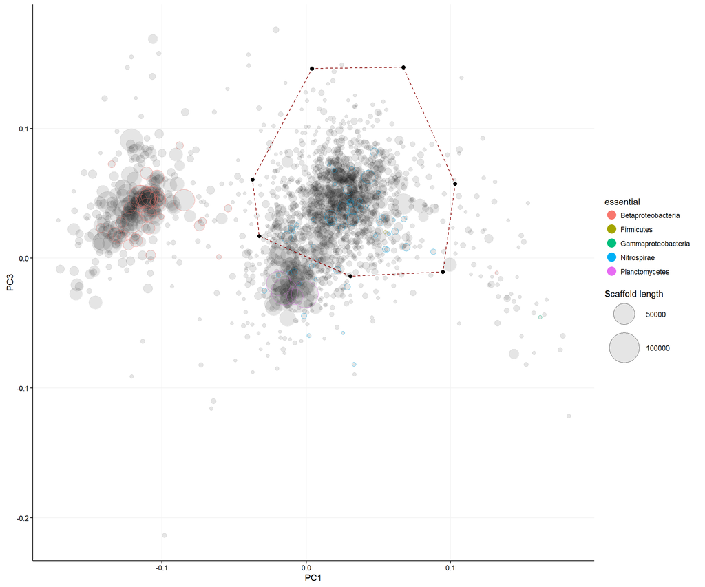

```r
p <- mmplot(data = dA,
            x = "PC1",
            y = "PC3",
            color = "essential",
            minlength = 1000)

#p
#sel <- mmplot_locator(p)

sel <- data.frame(PC1  =  c(-0.0373, 0.00392, 0.0672, 0.103, 0.0947, 0.0306, -0.0327),
                  PC3  =  c(0.0607, 0.146, 0.147, 0.0574, -0.0104, -0.0138, 0.0171))

mmplot_selection(p, sel)
```

The scaffolds included in the defined subspace are extracted using the `mmextract` function.

```r
dB <- mmextract(dA, sel)
```

The `mmstats` function applies to any extracted object. Hence, it can be used directly on the subset.

```r
mmstats(dB, ncov = 2)
```

```
##               General Stats
## n.scaffolds         1252.00
## GC.mean               55.60
## N50                 6296.00
## Length.total     5383386.00
## Length.max         54981.00
## Length.mean         4299.80
## Coverage.HPD          14.39
## Coverage.HPF1         12.79
## Ess.total             66.00
## Ess.unique            59.00
```

## Export the scaffolds

Finally the binned scaffolds are exported.

```r
mmexport(data = dB, assembly = assembly, file = "GWW_Nitrospira9.fa")
```